# Сортировки

## Сортировка пузырьком

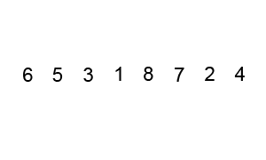

Сортировка пузырьком - это метод сортировки массивов и списков путем последовательного сравнения и обмена соседних элементов, если предшествующий оказывается больше последующего. В процессе выполнения данного алгоритма элементы с большими значениями оказываются в конце списка, а элементы с меньшими значениями постепенно перемещаются по направлению к началу списка. Образно говоря, тяжелые элементы падают на дно, а легкие медленно всплывают подобно пузырькам воздуха.

В сортировке методом пузырька количество итераций внешнего цикла определяется длинной списка минус единица, так как когда второй элемент становится на свое место, то первый уже однозначно минимальный и находится на своем месте.

Количество итераций внутреннего цикла зависит от номера итерации внешнего цикла, так как конец списка уже отсортирован, и выполнять проход по этим элементам смысла нет.

```r
bubble_sort <- function(x){
  n <- length(x)
  for(i in (n-1):1){
    for(j in 1:i){
      if(x[j] > x[j+1]){
        a <- x[j]
        x[j] <- x[j+1]
        x[j+1] <- a
      }
    }
  }
  return(x)
}

x <- sample(1:100,10)
print(x)
```

```
##  [1] 33 69 19  5 38  7 30 31 20 94
```

```r
print(bubble_sort(x))
```

```
##  [1]  5  7 19 20 30 31 33 38 69 94
```

## Сортировка слиянием

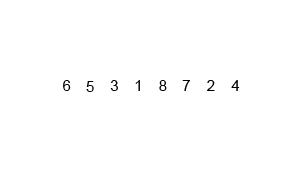

При сортировке слиянием массив разбивается пополам на 2 массива до тех пор, пока не останется по одному элементу. Потом начинается поочередное слияние, но только уже в отсортированном порядке. Более наглядно представлено на рисунках.

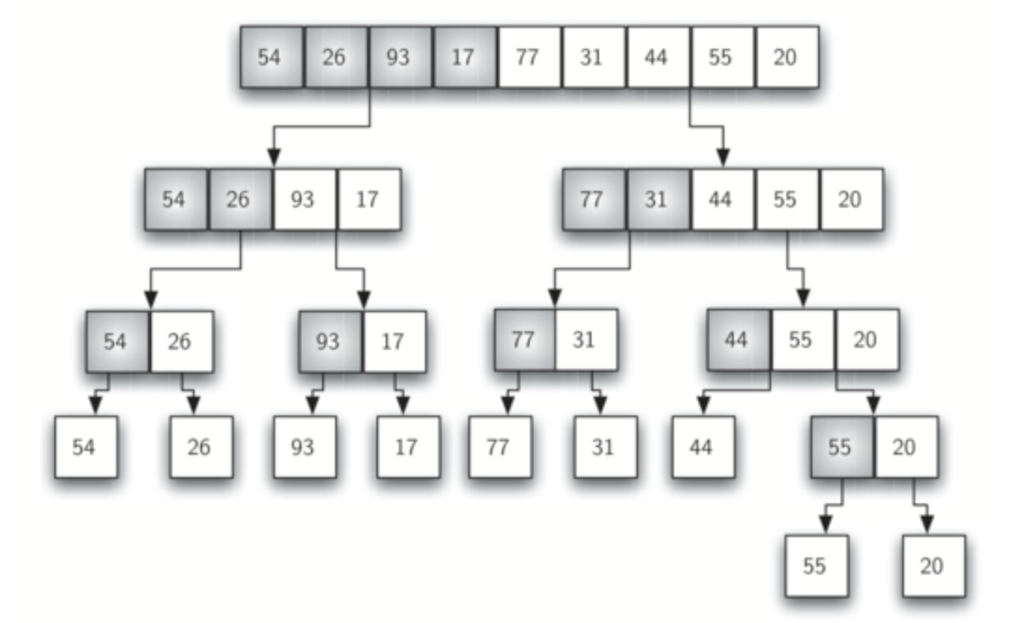

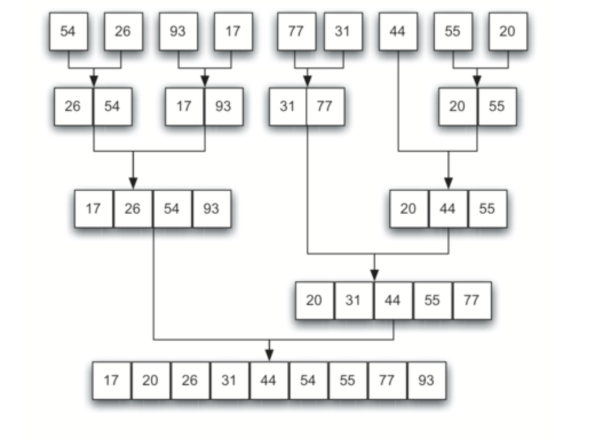

```r
MERGE <- function(A,B){
  C <- c()
  while(length(A)>0 & length(B)>0){
    if(A[1]<B[1]){
      C <- c(C,A[1])
      A <- A[-1]
    }else{
      C <- c(C,B[1])
      B <- B[-1]
    }
  }
  C <- c(C,A,B)
  return(C)
}

mergeSORT <- function(D){
  if(length(D)==1){
    return(D)
  }else{
    mid <- length(D)%/%2
    D <- MERGE(mergeSORT(D[1:mid]),mergeSORT(D[(mid+1):length(D)]))
  }
  return(D)
}

D <- sample(1:100,30)
print(D)
```

```
##  [1] 52 39 84 96 88 13 56 23 26  8 71 68 48 19 69  6 57 86 40 91 90 79 66
## [24] 16 37 49 74 15 46 12
```

```r
print(mergeSORT(D))
```

```
##  [1]  6  8 12 13 15 16 19 23 26 37 39 40 46 48 49 52 56 57 66 68 69 71 74
## [24] 79 84 86 88 90 91 96
```

## Сортировка вставками

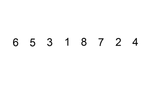

```r
insertion <- function(x){
  for(i in 2:length(x)){
    k <- i

    C <- x[i]
    for(j in (i-1):1){
      if(x[j] > C){
        x[j+1] <- x[j]
        k <- j
      }
    }
    x[k] <- C
  }
  return(x)
}

D <- sample(1:100,30)
print(D)
```

```
##  [1] 26 91 95 83 61 28 84 93 82  8 76 32 73 55  4 54 34 22 49 72 45 30 70
## [24] 79 66 90 35 27 41 37
```

```r
print(insertion(D))
```

```
##  [1]  4  8 22 26 27 28 30 32 34 35 37 41 45 49 54 55 61 66 70 72 73 76 79
## [24] 82 83 84 90 91 93 95
```

## Сортировка выбором

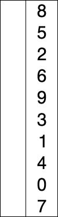

Алгоритм:

1. Найти наименьшее значение в списке.
2. Записать его в начало списка, а первый элемент - на место, где раньше стоял наименьший.
3. Снова найти наименьший элемент в списке. При этом в поиске не участвует первый элемент.
4. Второй минимум поместить на второе место списка. Второй элемент при этом перемещается на освободившееся место.
5. Продолжать выполнять поиcк и обмен, пока не будет достигнут конец списка

Иногда вместо минимума ищут максимум в массиве, тогда код может слегка отличаться. В качестве тренировки попробуйте дома построить алгоритм при нахождении максимума.

```r
selection <- function(x){
  for(i in 1:(length(x)-1)){
    m <- i
    for(j in (i+1):length(x)){
      if(x[j]<x[m]){
        m <- j
      }
    }
    a <- x[i]
    x[i] <- x[m]
    x[m] <- a
  }
  return(x)
}

x <- sample(-500:500, size = 8)
selection(x)
```

```
## [1] -420 -385 -369 -259 -252 -251 -123   79
```

## Сложности сортировок

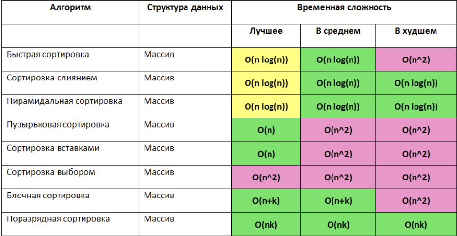